# Modelling COVID-19 in South Africa at a Provincial Level

## 9.6 Gauteng

Below we plot the projections for Gauteng.

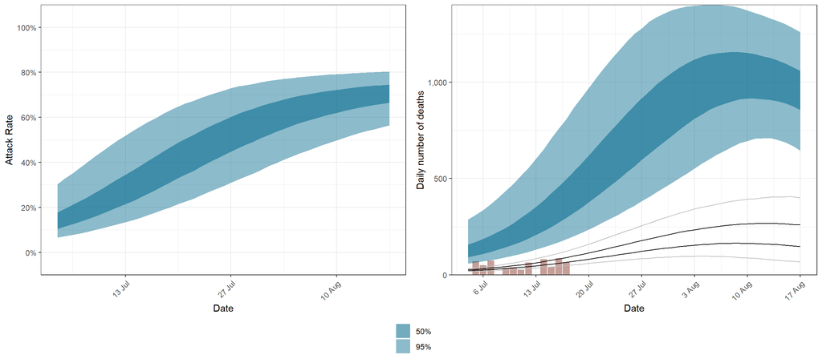

The attack rate and deaths over a longer period for both the constant mobility and increased mobility scenarios are plotted below:

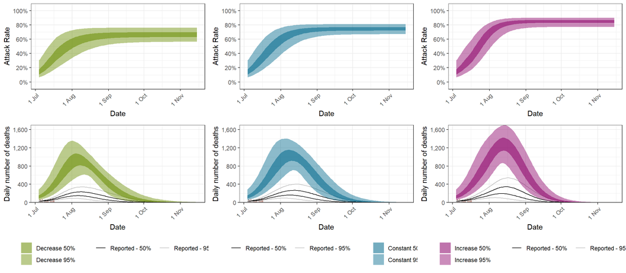

## 9.7 KwaZulu-Natal

Below we plot the projections for KwaZulu-Natal.

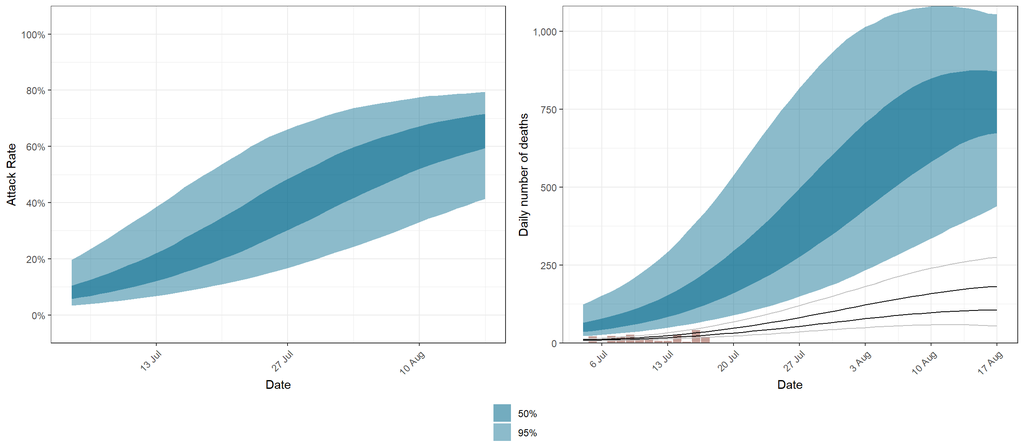

The attack rate and deaths over a longer period for both the constant mobility and increased mobility scenarios are plotted below:

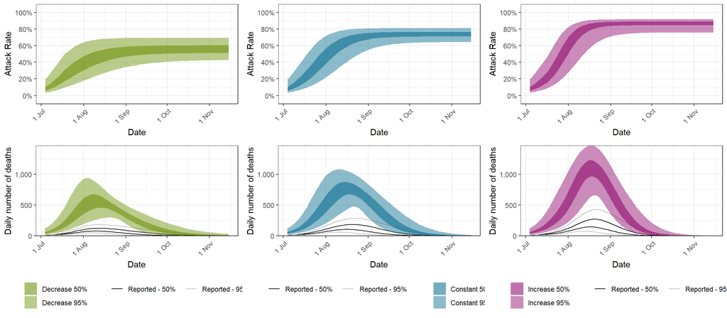

## 9.8 Other provinces

Below we plot the projections for the provinces other than, Western Cape, Eastern Cape, Gauteng and KwaZuly-Natal.

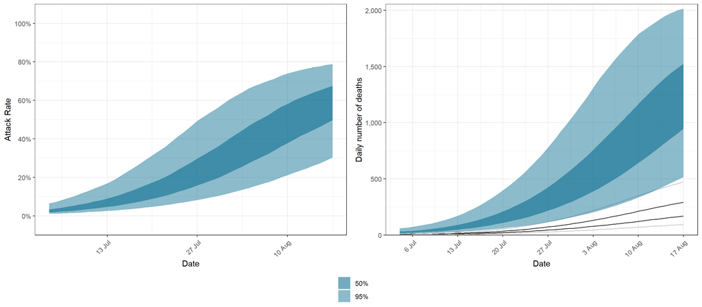

The attack rate and deaths over a longer period for both the constant mobility and increased mobility scenarios are plotted below:

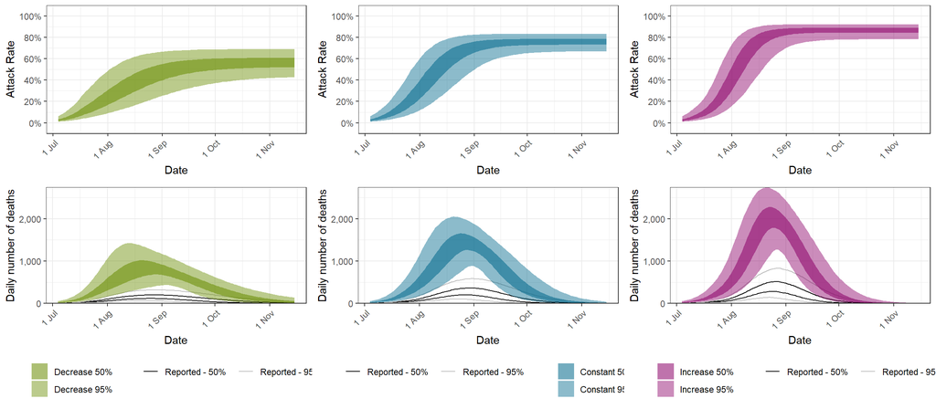

## 9.9 South Africa

We plot below the results for South Africa as a whole. This is the sum of the provincial projections.

The next 30 days the attack rate and deaths are increasing rapidly. The model predicts that within 30 days it is possible that deaths will exceed 500 per day and that more than 10% of the South African population may be infected.

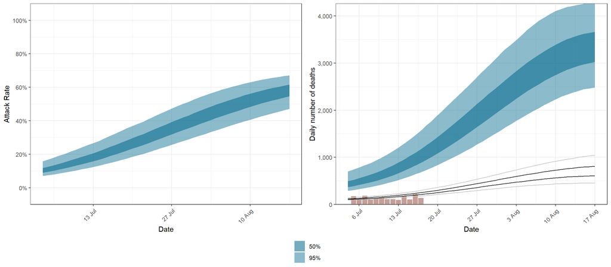

The attack rate and deaths over a longer period for both the constant mobility and increased mobility scenarios are plotted below:

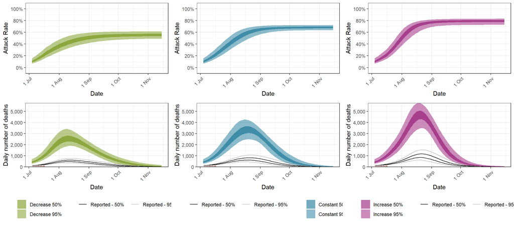

# 10 Backtesting

In the sections below the model is backtested. The backtesting assumes perfect knowledge of the mobility indexes to date, but tests the models with the 14 or 28 most recent days of death data excluded. The test is to see how well the model predicts forward over time.

## 10.1 14-day Backtest

Below we plot the backtesting for 14-days of recent data excluded as indicated by the black dotted line. The model is predicting more deaths for the Western Cape and Eastern Cape.

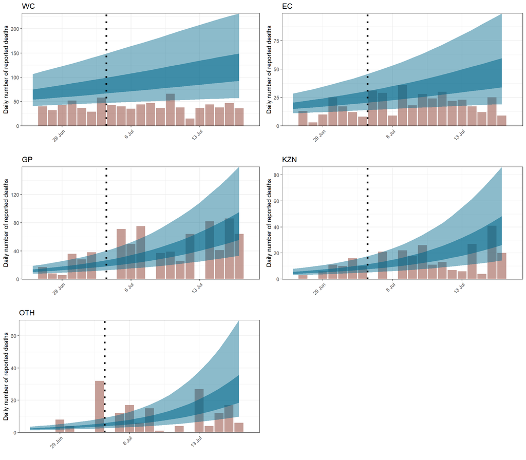

We provide residual plots for the above below, but it’s only really useful for the Western Cape as other provinces have many days of no deaths. For the Western Cape it seems that the model is projecting higher than the reported deaths.

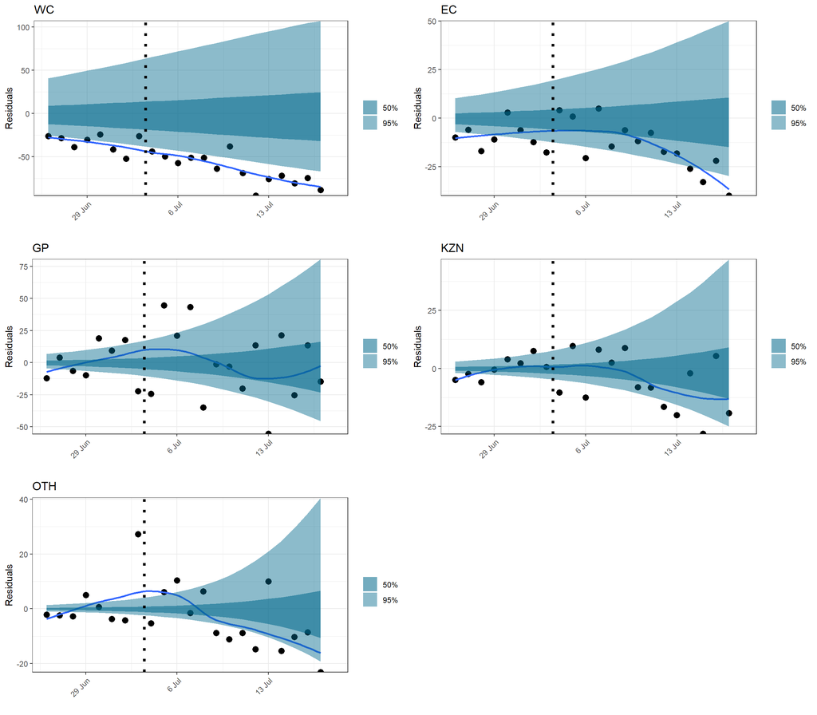

## 10.2 28-day Backtest

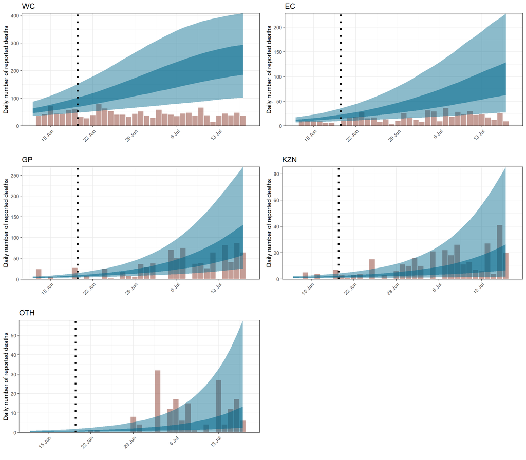

Below we plot the residuals for the above.

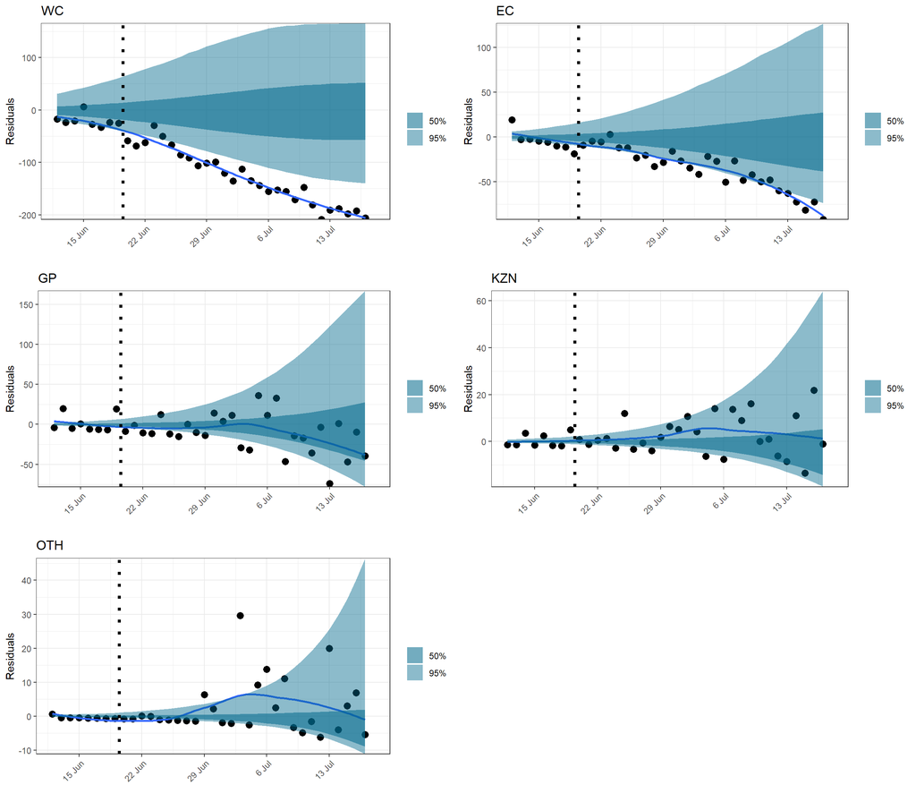

# 11 Discussion

## 11.2 Impact of Interventions

From the results it’s clear that $R_{t,m}$ in all provinces has reduced from the staring $R_{0,m}$ and this has slowed the spread of the epidemic in South Africa saving lives. However, in Europe the lockdowns have been able to reduce $R_{t}$ below 1 for various countries [17]. As shown here, South Africa’s lockdown and other interventions have not been as successful as in most the European countries shown in [17].

## 11.3 Lockdown - Level 4

Mobility has increased somewhat following the commencement of level 4 lockdowns. This results in an increasing the $R_{t,m}$ in various provinces since the start of May resulting in a corresponding increase in deaths two to four weeks later.

## 11.5 Further relaxation of lockdown

Projections on current mobility levels would already result in significant peaks in deaths. Further relaxation of lockdowns will result in increases in mobility, which would worsen the reproduction numbers.

Based on the modelling it is expected to result in roughly 31 000 more deaths by the end of the year. This ignores other impacts such as ICU availability and the impact on deaths from other causes which would be expected to increase these figures, but also the impact the homogeneity assumption which might be exacerbating this number.

## 11.6 Reducing Mobility

Reducing mobility could result in roughly -37 000 fewer deaths by the end of the year. This could happen via reverting lockdown to level 4 or, possibly, if other non-mobility interventions act as a dampener on any increases in the reproduction number. Again, this ignores other impacts such as ICU availability and the impact on deaths from other causes.

## 11.7 Differences between provinces

The large differences between the various provinces was surprising. Given the high prevalence in the Western Cape it may be prudent to enforce some screening or travel restrictions out of the province.

## 11.8 Relevance of IFR

The IFR is not treated as a parameter but as a constant with random noise. Changes to the IFR will change the modelled infections that correlate with the observed deaths. Sensitivity to the IFR could be modelled.

## 11.9 Using mobility data

Using mobility data is useful to not only measure the impact of government interventions but also include the societal response to those interventions (as they affect mobility). This means that changes in the reaction to new regulations can be modelled. It may also be useful going forward as many new regulations are introduced possibly at a provincial level to summarise the impact of interventions numerically.

## 11.10 Untangling mobility and other interventions

This paper projects mobility changes forward. We can see that as the model assigns some value to initiatives introduced at the start of level 4 around mask wearing and workplace screening. These are reducing the impact of increasing mobility such that in the Western Cape the $R_{t,m}$ actually reduced in level 4 compared to level 5.

It is difficult to know how this will continue forward especially given that the projections for the Western Cape is still exceeding the observations both in calibration and in backtesting.

## 11.11 Health system capacity

As ICU capacity is exhausted in the Western Cape it would seem likely that the mortality rate of infected individuals in the Western Cape would increase. This model needs to take account of that for two reasons:

1. Given the relationships between deaths and infections in this model as sudden increase in deaths due to capacity constraints would incorrectly be treated as a rise in infections.
2. To project forward accurately the expected deaths this model needs to allow for future capacity constraints as well.

## 11.12 Backtesting & poor fit to Western Cape (and Eastern Cape)

Backtesting shows reasonable performance of the model at least over a shorter 28-day and 14-day time periods. There is some bias in which appears to be over-predicting reported deaths in the last week or two.

Some possible reasons are:

- Under- or late-reporting increasing in recent week or two.
- Increased mobility being muted by other interventions increasing.
- Some form of heterogeneous susceptibility kicking in.
- Over-estimating of the epidemic to date due to under-estimated IFRs.
- Not enough data yet to adjust the curve for the latest emerging experience.

These will be investigated to the extent possible.

## 11.13 Improving the Model

The model is still projecting too high deaths for Western Cape and Eastern Cape in calibration and/or backtesting.

The author intends to investigate the introduction of autoregressive process as per [3] to model further residuals that cannot seem to be captures by existing parameters. These may be reflecting other NPIs, general population awareness and behaviour adjustment or other unmodelled disease effects.

Other areas to investigate in this regard:

- The potential for increasing reporting delays in a rising epidemic and the impact here.
- The potential for changes in underreporting and it’s impact here.
- Heterogeneous susceptibility or lives that may be not susceptible may impact results here.

## 11.14 Further Work

Along with the above, the author intends to investigate the following:

- Search and include further indexes that may track other interventions to model their effect.
- Analyse the sensitivity of results to changes in IFR.
- Consider spreading deaths backwards based on estimated reporting delays.
- Analyse the impact of different assumptions of distribution of deaths on the sensitivity of projections.
- Consider incorporating health system constraints and it’s impact on IFRs.
- Consider adjusting completeness of reporting over time.

# 12 Detailed Assumptions and Methodology

The model assumes that current reproduction number, $R_{t,m}$, is a function of the initial reproduction number, $R_{0,m}$, and mobility changes over time. It then calculates infections as a function of $R_{t,m}$ over time, and then, using these infections calculates deaths from the infections based on a distribution of time to death. Various prior distributions are assumed. The model structure is identical to that in [1] but is briefly documented below. The parameters are estimated jointly using a single hierarchical model covering all provinces. This means that data in different provinces are combined to inform all parameters in the model. As per [1], fitting was done in R using Stan with an adaptive Hamiltonian Monte Carlo sampler.

## 12.1 The Model

The model is documented here but is as per in [1], apart from the simplification of mobility indexes to a single index. The model assumes a base reproduction number ($R_{0,m}$) for each province ($m$) and then it models future values of the reproduction number using mobility indexes as follows:

$R_{t,m}=R_{0,m}\cdot2\cdot\phi^{-1}(-(\alpha+\alpha_{m}^s)I_{t,m}^{\alpha}-(\beta+\beta_{m}^s)I_{t,m}^{\beta})$

Here:

- $t$ is the day.
- $\phi^{-1}$ is the inverse logit function.
- $I_{t,m}^{\alpha}$ is the average mobility indexes from Google Mobility [5] data for each province over time. Typical movements are presented by 0 and atypically movements are represented by increases or decreases to the above.
- $\alpha$ is the effect of $I_{t,m}^{\alpha}$ on $R_{t,m}$ independent of province.
- $\alpha_{m}^s$ is the province specific effect of $I_{t,m}^{\alpha}$ on $R_{t,m}$.
- $I_{t,m}^{\beta}$ is the effect of other interventions introduced with level 4 lockdown. $I_{t,m}^{\beta}$ is 0 before the start of level 4 and remains 1 after the start of level 4 lockdown.
- $\beta$ is the effect of $I_{t,m}^{\beta}$ on $R_{t,m}$ independent of province.
- $\beta_{m}^s$ is the province specific effect of $I_{t,m}^{\beta}$ on $R_{t,m}$.

Infections are modelled as:

$c_{t,m}=S_{t,m}R_{t,m}\sum_{\tau=0}^{t-1}c_{\tau,m}g_{t-\tau}$ where $S_{t,m}=1 - \frac{\sum_{i=0}^{t-1}c_{i,m}}{N_{m}}$.

Infections, $c_{t,m}$ at time $t$ are a function of proportion of population not yet infected ($S_{t,m}$), the reproduction number ($R_{t,m}$) and infections prior to that $c_{\tau,m}$ as well as an infectiousness curve $g_{t-\tau}$. $N_m$ is the population in province $m$.

Deaths, $d_{t,m}$ are modelled as:

$d_{t,m}=ifr_{m}^*\sum_{\tau=0}^{t-1}c_{\tau,m}\pi_{t-\tau}$

Here:

- $ifr_{m}^*$ is the average infection fatality rate (IFR) in the province (with random noise added).
- $\pi_{t-\tau}$ is a distribution of time to death since infection.

We model completeness of reporting as random noise from a Beta distribution:

$\psi_m \sim B(\mu_mv_m,(1-\mu_m)v_m)$

Here:

- $\mu_m$ is as per observed completeness of reporting of deaths in each province.
- $v_m$ is set such that two times the standard deviation of $\psi_m$ is 0.15.

Reported deaths, $d'_{t,m}$ are then:

$d'_{t,m}=d_{t,m}\psi_m$

Reported daily deaths $D'_{t,m}$ are assumed to have the following distribution:

$D'_{t,m} \sim Negative\ Binomial(d'_{t,m},d'_{t,m}+ \frac{{d'}_{t,m}^2}{\phi})$

If $Y \sim N(\mu,\sigma)$ then we define $N^{+}$ to mean the distribution of $|Y| \sim N^{+}(\mu,\sigma)$.

We assume that:

$\phi \sim N^{+}(0,5)$

Then: $d'_{t,m}=E(D'_{t,m})$

## 12.2 Prior Assumptions and Random Noise

The following assumptions are taken as is from [1] except for where indicated.

We add random noise to the IFR as follows:

$ifr_{m}^*=ifr_{m}\cdot N(1,0.1)$

$\alpha \sim N(0,0.5)$

$\beta \sim N^{+}(0,1)$

The above distribution for $\beta$ has been increased to reflect [8] which indicated an effect of mask wearing. In this paper a relative risk of 0.56 is indicated for mask wearing in non-health-care settings. The above prior would indicate a 0.62 expected relative risk. $\beta$ is not a parameter in the model used in [1].

Then for the provincial specific index effects we use:

$\alpha_{m}^s \sim N(0,\gamma^{\alpha})$ with $\gamma^{\alpha} \sim N^{+}(0,0.5)$

$\beta_{m}^s \sim N(0,\gamma^{\beta})$ with $\gamma^{\beta} \sim N^{+}(0,0.5)$

The $R_{0,m}$ are defined to be distributed normally as follows:

$R_{0,m} \sim N(3.28,\kappa)$ with $\kappa \sim N^{+}(0,0.5)$

Infectiousness follows this distribution:

$g \sim Gamma(6.5,0.62)$

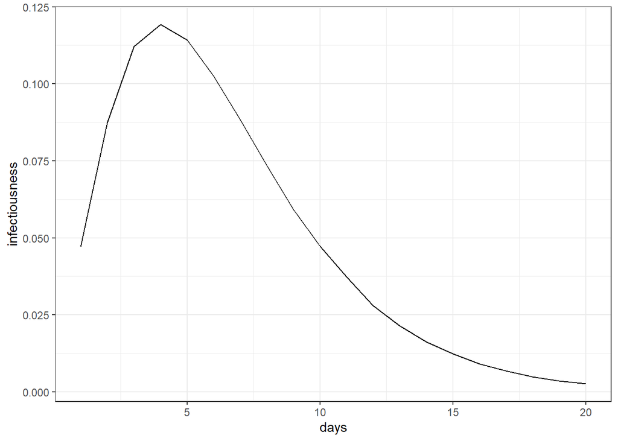

Time to death follows this distribution:

$\pi \sim Gamma(5.1,0.86)+Gamma(17.8,0.45)$

The distribution of time to death is plotted below.

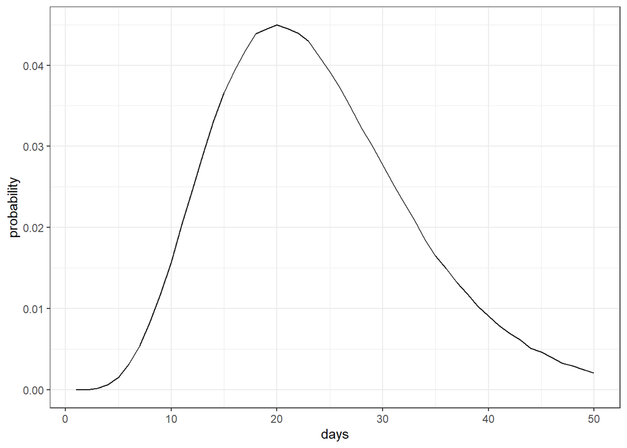

The above implies an average time to death of 23 days.

## 12.3 Death and Confirmed Case Data

Death and case data were used from [4]. This data set contains, amongst other, provincial case and deaths data digitised mainly from daily tweets by National Institute of Communicable Diseases (NICD).

We note again that the model calibrates to only the deaths. The reason for not calibrating to confirmed cases is that the bias in the testing is unknown. The degree to which testing has focussed on symptomatic and people seeking medical treatment or hospital treatment is unknown and could have changed over time. This would present a biased estimate and would require adjustment in this model.

Based on limited death data, provinces were aggregated as follows:

- EC – Eastern Cape
- GP – Gauteng
- KZN – KwaZulu Natal
- WC – Western Cape
- OTH (all other provinces)

## 12.4 Infection Fatality Rates (IFR)

The IFR ($ifr_{m}$) for each province was calculated using the output of the squire R package [18]. It produces an age-specific infection attack rates (IAR), infections and deaths. The per age band IFR were used together with the per age band IAR and these were applied to provincial populations [19]. The IFRs from squire package are based on [20], [21] and [18].

The projection was done doing the default parameters for South Africa and the resultant attack rate ($a_{x}$) and IFR ($ifr_{x}$) for each 5-year age band was obtained ($x$).

Additionally HIV prevalence by age-band and province, $i_{x,m}^{HIV}$ was taken into account from [22] as well as results from [12]. In [12] it is shown that lives with HIV have higher COVID-19 mortality once infected. Based on the these results we assume three times COVID-19 mortality below 55 and double mortality from age 55 upwards ($m_x^{HIV}$).

These $a_{x}$ and $ifr_{x}$ and HIV adjustments were then applied to the South African population per province and age band as per [19] and weighted IFRs calculated as follows.

$ifr_{m}=\frac{\sum_{x}N_{x,m} \cdot a_{x} \cdot ifr_{x}( (1-i_{x,m}^{HIV}) +i_{x,m}^{HIV} \cdot m_x^{HIV})}{\sum_{x}N_{x,m}}$

Here $N_{x,m}$ is the population in a particular province ($m$) and age band ($x$).

Below we tabulate the resultant $ifr_{m}$:

| Province | IFR |
| --- | --- |
| EC | 0.64% |
| GP | 0.44% |
| KZN | 0.47% |
| WC | 0.5% |
| OTH | 0.5% |
| South Africa | 0.49% |

The differences between provinces reflect the different age profiles in those provinces as per [19]. This seems low compared to the IFRs in [15], but may be reasonable given the younger profile of the South African population.

## 12.5 Completeness of Reporting of Deaths

Based excess deaths estimated in [23], [16] and [9] and reported deaths in [4] one can estimate the completeness of reporting. Below excess deaths as derived in [9] over 6 May 2020 to 7 July 2020 is compared with reported deaths for the same period (per [4]). The assumptions is that 90% of excess deaths are COVID-19 related.

For OTH we have assumed the same ratio as per Eastern cape, Gauteng and KwaZulu-Natal combined.

| Province | Excess Deaths | Reported Deaths | COVID-19 Excess | Completeness |
| --- | --- | --- | --- | --- |
| EC | 3299 | 546 | 2969.1 | 0.18 |
| GP | 2779 | 463 | 2501.1 | 0.19 |
| KZN | 1079 | 169 | 971.1 | 0.17 |
| WC | 3694 | 2074 | 3324.6 | 0.62 |
| OTH | NA | NA | NA | 0.18 |

## 12.6 Mobility Indexes

Google has released aggregated mobility data for various countries and for sub-regions in those countries. These data is generated from devices that have enabled the Location History in Google Maps. This feature is available both on Android and iOS devices but is off by default.

For South Africa, these data contain the mobility indexes for each province. These are described in [5] as follows:

- Grocery & pharmacy: Mobility trends for places like grocery markets, food warehouses, farmers markets, specialty food shops, drug stores, and pharmacies.
- Parks: Mobility trends for places like local parks, national parks, public beaches, marinas, dog parks, plazas, and public gardens.
- Transit stations: Mobility trends for places like public transport hubs such as subway, bus, and train stations.
- Retail & recreation: Mobility trends for places like restaurants, cafes, shopping centres, theme parks, museums, libraries, and movie theatres.
- Residential: Mobility trends for places of residence.
- Workplaces: Mobility trends for places of work.

These measure relative changes in mobility in above dimensions relative to a baseline established before the epidemic. For example, -30% implies a 30% reduction in mobility from pre-COVID-19 mobility.

As per [7] these data were combined into an average mobility index for each province which was an average of all mobility indexes excluding:

- Residential
- Parks

In [1] three indexes were used (Residential, Transit and the rest). This was reduced for this paper due to limited data.

We calculated indexes for OTH by weighting the individual provinces by population.

# 13 Author

This report was prepared by Louis Rossouw. Please get in contact with Louis Rossouw if you have comments or wish to receive this regularly.

**Louis Rossouw**  
Head of Research & Analytics  
Gen Re | Life/Health Canada, South Africa, Australia, NZ, UK & Ireland  
Email: LRossouw@GenRe.com Mobile: +27 71 355 2550

*The views in this document represents that of the author and may not represent those of Gen Re. Also note that given the significant uncertainty involved with the parameters, data and methodology care should be taken with these numbers and any use of these numbers.*

# References

[1] M. Vollmer *et al.*, “Report 20: A sub-national analysis of the rate of transmission of COVID-19 in Italy,” Imperial College London, 2020 [Online]. Available: https://www.imperial.ac.uk/mrc-global-infectious-disease-analysis/covid-19/report-20-italy/

[2] T. Mellan *et al.*, “Report 21: Estimating COVID-19 cases and reproduction number in Brazil,” Imperial College London, 2020 [Online]. Available: https://www.imperial.ac.uk/mrc-global-infectious-disease-analysis/covid-19/report-21-brazil/

[3] H. Unwin *et al.*, “Report 23: State-level tracking of COVID-19 in the United States,” Imperial College London, 2020 [Online]. Available: https://www.imperial.ac.uk/mrc-global-infectious-disease-analysis/covid-19/report-23-united-states/

[4] V. Marivate *et al.*, “Coronavirus disease (COVID-19) case data - South Africa.” Zenodo, 2020 [Online]. Available: https://zenodo.org/record/3888499

[5] Google LLC, “Google COVID-19 community mobility reports.” 2020 [Online]. Available: https://www.google.com/covid19/mobility/

[6] R Core Team, *R: A language and environment for statistical computing*. Vienna, Austria: R Foundation for Statistical Computing, 2019 [Online]. Available: https://www.R-project.org/

[7] P. Nouvellet *et al.*, “Report 26: Reduction in mobility and COVID-19 transmission,” Imperial College London, 2020 [Online]. Available: https://www.imperial.ac.uk/mrc-global-infectious-disease-analysis/covid-19/report-26-mobility-transmission/

[8] D. K. Chu *et al.*, “Physical distancing, face masks, and eye protection to prevent person-to-person transmission of SARS-CoV-2 and COVID-19: A systematic review and meta-analysis,” *The Lancet*, vol. 395, no. 10242, pp. 1973–1987, Jun. 2020, doi: 10.1016/S0140-6736(20)31142-9. [Online]. Available: https://www.thelancet.com/journals/lancet/article/PIIS0140-6736(20)31142-9/fulltext

[9] D. Bradshaw, R. Laubscher, R. Dorrington, P. Groenewald, and T. Moultrie, “Report on weekly deaths in South Africa 1 January - 7 July 2020 (Week 26),” Burden of Disease Research Unit, South African Medical Research Council [Online]. Available: https://www.samrc.ac.za/sites/default/files/files/2020-07-15/WeeklyDeaths7July2020_0.pdf

[10] J. D. Goodman and M. Rothfield, “1 in 5 New Yorkers may have had Covid-19, antibody tests suggest,” *New York Times* [Online]. Available: https://www.nytimes.com/2020/04/23/nyregion/coronavirus-antibodies-test-ny.html

[11] A. Winde, “Update on the coronavirus by Premier Alan Winde.” Western Cape Government [Online]. Available: https://coronavirus.westerncape.gov.za/news/update-coronavirus-premier-alan-winde-6-june

[12] M.-A. Davies, “Brief update on surveilance of COVID-19 infections in the Western Cape.” 03-Jun-2020. [Online]. Available: http://www.medicine.uct.ac.za/covid19-echo-clinic

[13] G. E. P. Box, “Robustness in the strategy of scientific model building,” in *Robustness in statistics*, Elsevier, 1979, pp. 201–236 [Online]. Available: https://doi.org/10.1016/b978-0-12-438150-6.50018-2

[14] Independent Communications Authority of South Africa, “The state of the ICT sector report in South Africa,” 2020 [Online]. Available: https://www.icasa.org.za/legislation-and-regulations/state-of-the-ict-sector-in-south-africa-2020-report

[15] G. Meyerowitz-Katz and L. Merone, “A systematic review and meta-analysis of published research data on COVID-19 infection-fatality rates” [Online]. Available: https://www.medrxiv.org/content/10.1101/2020.05.03.20089854v3

[16] D. Bradshaw, R. Laubscher, R. Dorrington, P. Groenewald, and T. Moultrie, “Report on weekly deaths in South Africa 1 January - 30 June 2020 (Week 26),” Burden of Disease Research Unit, South African Medical Research Council [Online]. Available: https://www.samrc.ac.za/sites/default/files/files/2020-07-08/WeeklyDeaths30June2020.pdf

[17] S. Flaxman *et al.*, “Report 13: Estimating the number of infections and the impact of non-pharmaceutical interventions on COVID-19 in 11 European countries,” Imperial College London, 2020 [Online]. Available: https://www.imperial.ac.uk/mrc-global-infectious-disease-analysis/covid-19/report-13-europe-npi-impact/

[18] P. Walker *et al.*, “Report 12: The global impact of COVID-19 and strategies for mitigation and suppression,” Imperial College London, 2020 [Online]. Available: https://www.imperial.ac.uk/mrc-global-infectious-disease-analysis/covid-19/report-12-global-impact-covid-19/

[19] Statistics South Africa, “Mid-year population estimates 2019,” Republic of South Africa, 2019 [Online]. Available: https://www.statssa.gov.za/publications/P0302/P03022019.pdf

[20] R. Verity *et al.*, “Estimates of the severity of coronavirus disease 2019: A model-based analysis,” *The Lancet Infectious Diseases*, vol. 20, no. 6, pp. 669–677, Jun. 2020, doi: 10.1016/s1473-3099(20)30243-7. [Online]. Available: https://www.thelancet.com/journals/laninf/article/PIIS1473-3099(20)30243-7/fulltext

[21] N. Ferguson *et al.*, “Report 9: Impact of non-pharmaceutical interventions (NPIs) to reduce COVID19 mortality and healthcare demand,” Imperial College London, 2020 [Online]. Available: https://www.imperial.ac.uk/mrc-global-infectious-disease-analysis/covid-19/report-9-impact-of-npis-on-covid-19/

[22] L. Johnson, R. Dorrington, and H. Moolla, “Progress towards the 2020 targets for hiv diagnosis and antiretroviral treatment in south africa,” *Southern African Journal of HIV Medicine*, vol. 18, no. 1, p. 8, 2017, doi: 10.4102/sajhivmed.v18i1.694. [Online]. Available: https://sajhivmed.org.za/index.php/hivmed/article/view/694

[23] D. Bradshaw, R. Laubscher, R. Dorrington, P. Groenewald, and T. Moultrie, “Report on weekly deaths in South Africa 1 January - 23 June 2020 (Week 25),” Burden of Disease Research Unit, South African Medical Research Council [Online]. Available: https://www.samrc.ac.za/sites/default/files/files/2020-07-01/WeeklyDeaths23June2020_0.pdf